# GuitarFast: Quick Start Guide

## Overview

**GuitarFast** visualizes how RNA-related genomic features (m6A peaks, RBP binding sites, etc.) distribute across transcript landmarks: transcription start site (TSS), start codon, stop codon, and transcription end site (TES).

It supports three transcript views:

- **tx** – all transcripts (promoter / RNA / tail)
- **mrna** – mRNA (promoter / 5’UTR / CDS / 3’UTR / tail)
- **ncrna** – long non-coding RNA (promoter / ncRNA / tail)

GuitarFast is a performance-optimized fork of the Guitar Bioconductor package (v2.26.0), running 3-6x faster with numerically identical output. See `vignette("GuitarFast-Benchmark")` for details.

## Setup

```r
library(GuitarFast)
library(GenomicFeatures)

# Toy transcriptome annotation (subset of mm10)
txdb <- loadDb(system.file("extdata", "mm10_toy.sqlite", package = "GuitarFast"))

# BED file with 1000 m6A peaks
bed_file <- system.file("extdata", "m6A_mm10_exomePeak_1000peaks_bed12.bed",
                         package = "GuitarFast")
```

## 1. Basic Distribution Plot

The simplest usage: provide a TxDb and a BED file.

[output not shown]

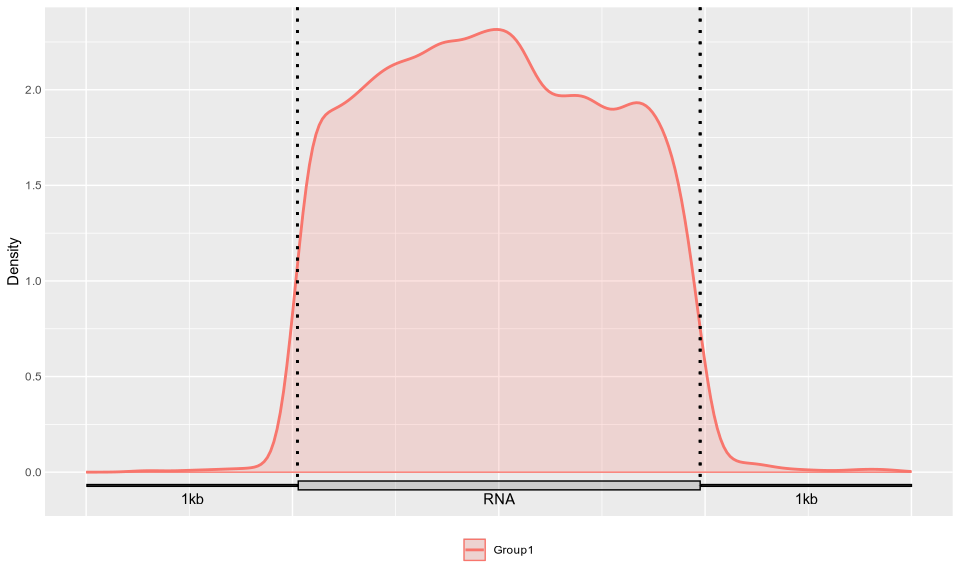

```r
GuitarPlot(txTxdb = txdb,
           stBedFiles = list(bed_file),
           enableCI = FALSE,
           pltTxType = c("tx"))
```

The x-axis represents the normalized transcript position (0 = TSS, 1 = TES). The y-axis shows the density of genomic features. Vertical dotted lines mark transcript component boundaries.

## 2. Confidence Intervals

Bootstrap confidence intervals show the statistical reliability of the density curve. The default uses 200 resamples.

[output not shown]

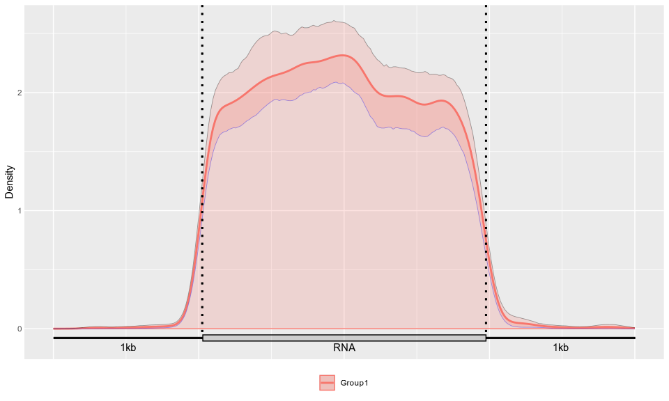

```r
GuitarPlot(txTxdb = txdb,
           stBedFiles = list(bed_file),
           enableCI = TRUE,
           pltTxType = c("tx"))
```

For higher precision (at the cost of speed), increase `CI_ResamplingTime`:

```r
GuitarPlot(txTxdb = txdb,
           stBedFiles = list(bed_file),
           enableCI = TRUE,
           CI_ResamplingTime = 1000,
           pltTxType = c("tx"))
```

## 3. mRNA-Specific View

The mRNA view splits the transcript into 5 components, revealing whether features cluster near the start codon, stop codon, or UTRs:

[output not shown]

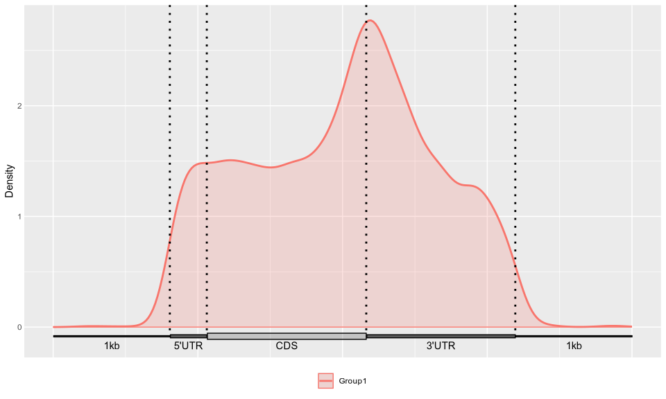

```r
GuitarPlot(txTxdb = txdb,
           stBedFiles = list(bed_file),
           enableCI = FALSE,
           pltTxType = c("mrna"))
```

## 4. ncRNA View

[output not shown]

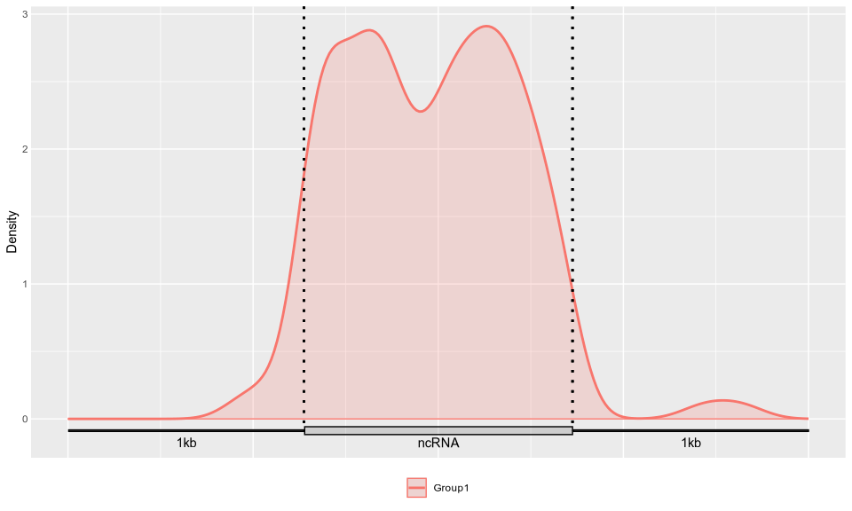

```r
GuitarPlot(txTxdb = txdb,
           stBedFiles = list(bed_file),
           enableCI = FALSE,
           pltTxType = c("ncrna"))
```

## 5. Compare Multiple Groups

Pass multiple BED files and name them:

[output not shown]

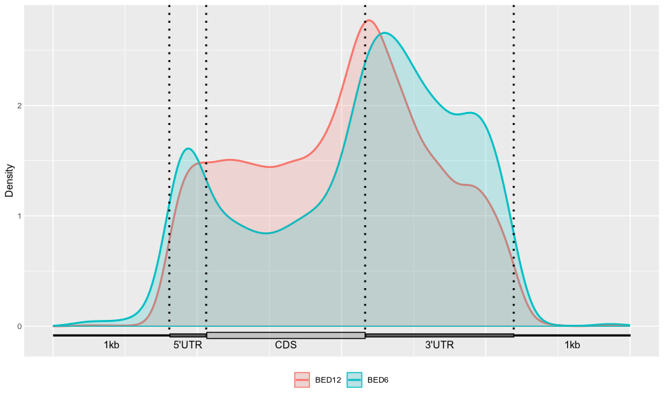

```r
bed12 <- system.file("extdata", "m6A_mm10_exomePeak_1000peaks_bed12.bed",
                      package = "GuitarFast")
bed6  <- system.file("extdata", "m6A_mm10_exomePeak_1000peaks_bed6.bed",
                      package = "GuitarFast")

GuitarPlot(txTxdb = txdb,
           stBedFiles = list(bed12, bed6),
           stGroupName = c("BED12", "BED6"),
           enableCI = FALSE,
           pltTxType = c("mrna"))
```

## 6. GRangesList Input

You can pass genomic features as GRanges objects directly instead of BED files:

[output not shown]

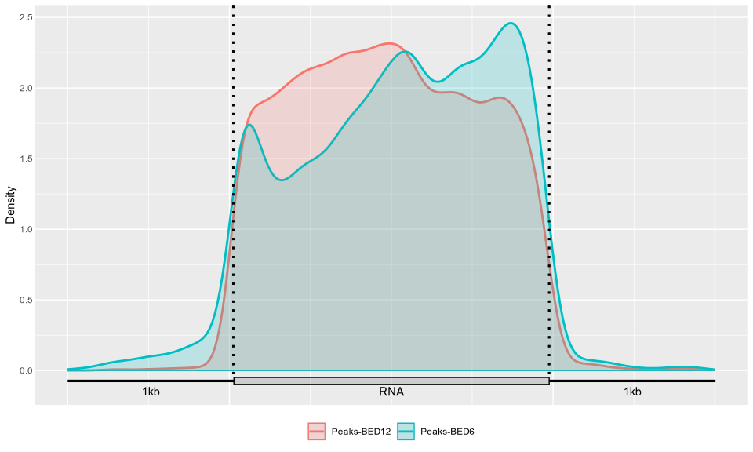

```r
library(rtracklayer)

gr1 <- blocks(import(bed12))
gr2 <- import(bed6)

GuitarPlot(txTxdb = txdb,
           stGRangeLists = list(gr1, gr2),
           stGroupName = c("Peaks-BED12", "Peaks-BED6"),
           enableCI = FALSE,
           pltTxType = c("tx"))
```

## 7. Flanking Regions

By default, 1kb promoter and tail flanking regions are shown. To hide them:

[output not shown]

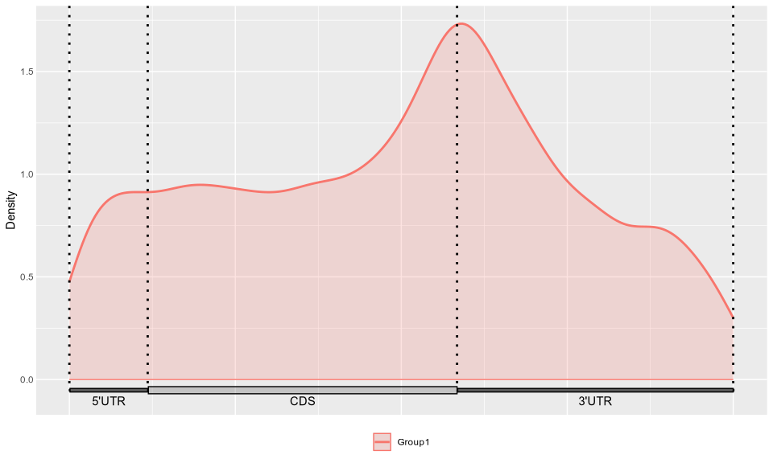

```r
GuitarPlot(txTxdb = txdb,
           stBedFiles = list(bed_file),
           enableCI = FALSE,
           headOrtail = FALSE,
           pltTxType = c("mrna"))
```

## 8. Save PDFs for All Transcript Types

When `miscOutFilePrefix` is set, one PDF is saved per transcript type:

```r
GuitarPlot(txTxdb = txdb,
           stBedFiles = list(bed_file),
           enableCI = TRUE,
           pltTxType = c("tx", "mrna", "ncrna"),
           miscOutFilePrefix = "my_output")
# Saves: my_output_tx_test.pdf, my_output_mrna_test.pdf, my_output_ncrna_test.pdf
```

## 9. Pre-build GuitarTxdb for Reuse

Building the transcriptome coordinate system takes ~1-2 seconds. If you are plotting multiple datasets against the same genome, build it once and save:

```r
# Build once
guitarTxdb <- makeGuitarTxdb(txdb = txdb, txPrimaryOnly = FALSE)
```

```
#> [1] "There are 2946 transcripts of 2946 genes in the genome."
#> [1] "total 2946 transcripts extracted ..."
#> [1] "total 2719 transcripts left after ambiguity filter ..."
#> [1] "total 2719 transcripts left after check chromosome validity ..."
#> [1] "total 1342 mRNAs left after component length filter ..."
#> [1] "total 307 ncRNAs left after ncRNA length filter ..."
#> [1] "generate components for all tx"
#> [1] "generate components for mRNA"
#> [1] "generate components for lncRNA"
#> [1] "generate chiped transcriptome"
#> [1] "generate coverage checking ranges for tx"
#> [1] "generate coverage checking ranges for mrna"
#> [1] "generate coverage checking ranges for ncrna"
```

```r
# Save to disk
save(guitarTxdb, file = "my_guitarTxdb.RData")
```

Load and reuse in subsequent runs:

```r
GuitarPlot(txGuitarTxdb = "my_guitarTxdb.RData",
           stBedFiles = list(bed_file),
           enableCI = TRUE,
           pltTxType = c("tx"))
```

## 10. Custom Component Proportions

Control how wide each transcript component appears in the plot:

```r
guitarTxdb <- makeGuitarTxdb(
  txdb = txdb,
  txMrnaComponentProp = c(0.1, 0.15, 0.6, 0.05, 0.1),
  txLncrnaComponentProp = c(0.2, 0.6, 0.2),
  pltTxType = c("tx", "mrna", "ncrna"),
  txPrimaryOnly = FALSE
)
```

```
#> [1] "There are 2946 transcripts of 2946 genes in the genome."
#> [1] "total 2946 transcripts extracted ..."
#> [1] "total 2719 transcripts left after ambiguity filter ..."
#> [1] "total 2719 transcripts left after check chromosome validity ..."
#> [1] "total 1342 mRNAs left after component length filter ..."
#> [1] "total 307 ncRNAs left after ncRNA length filter ..."
#> [1] "generate components for all tx"
#> [1] "generate components for mRNA"
#> [1] "generate components for lncRNA"
#> [1] "generate chiped transcriptome"
#> [1] "generate coverage checking ranges for tx"
#> [1] "generate coverage checking ranges for mrna"
#> [1] "generate coverage checking ranges for ncrna"
```

The proportions correspond to:

- **mRNA**: promoter, 5’UTR, CDS, 3’UTR, tail
- **ncRNA**: promoter, ncRNA, tail

## 11. GTF/GFF Annotation

Instead of a TxDb object, you can use a GTF/GFF file or a genome version string:

```r
# From GTF
GuitarPlot(txGTF = "path/to/annotation.gtf",
           stBedFiles = list(bed_file),
           enableCI = FALSE)

# From GFF3
GuitarPlot(txGFF = "path/to/annotation.gff3",
           stBedFiles = list(bed_file),
           enableCI = FALSE)

# From genome version (downloads TxDb automatically, requires internet)
GuitarPlot(txGenomeVer = "hg38",
           stBedFiles = list(bed_file))
```

## Key Parameters

| Parameter | Default | Description |
| --- | --- | --- |
| `txTxdb` | NULL | TxDb object for gene annotation |
| `txGTF` / `txGFF` | NULL | Path to GTF/GFF annotation file |
| `txGenomeVer` | NULL | Genome version (hg19, hg38, mm9, mm10) |
| `txGuitarTxdb` | NULL | Path to saved GuitarTxdb .RData file |
| `stBedFiles` | NULL | List of BED file paths |
| `stGRangeLists` | NULL | List of GRanges/GRangesList objects |
| `stGroupName` | NULL | Custom group names |
| `enableCI` | TRUE | Show bootstrap confidence intervals |
| `CI_ResamplingTime` | 200 | Number of bootstrap resamples |
| `pltTxType` | c(“tx”,“mrna”,“ncrna”) | Transcript types to plot |
| `headOrtail` | TRUE | Include 1kb flanking regions |
| `stSampleNum` | 10 | Points sampled per genomic feature |
| `miscOutFilePrefix` | NA | Set to save PDFs (one per txType) |
| `mapFilterTranscript` | TRUE | Filter transcript mappings by length |
| `txPrimaryOnly` | FALSE | Use only primary (longest) transcripts |
| `adjust` | 1 | Bandwidth adjustment for density estimation |